# 18/19 DPH101 final B.Comparing Means

dizhen

2019.12.27

## B.Comparing Means

### Step1. Data

```r
pre <- c(22,63.3,96.0,9.2,3.1,50,33,69,64,18.8,0,34)
post<- c(63.5,91.5,59,37.8,10.1,19.6,41,87.8,86,55,88,40)
diff <- pre-post
diff
```

```
##  [1] -41.5 -28.2  37.0 -28.6  -7.0  30.4  -8.0 -18.8 -22.0 -36.2 -88.0
## [12]  -6.0
```

Assess the assumption of norrmality.

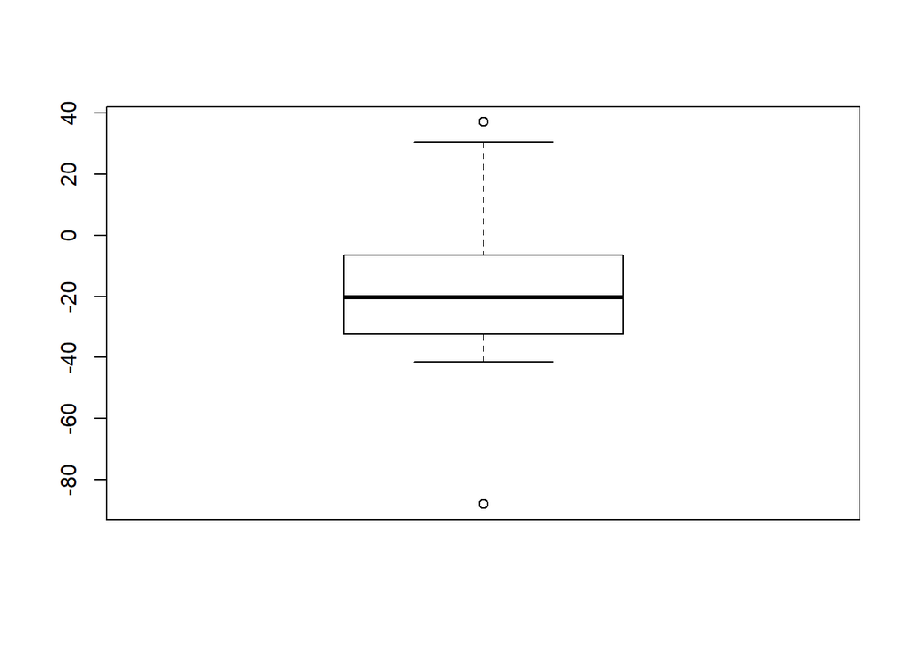

```r
boxplot(diff)
```

### Step2. Assumptions

1. The sample data are dependent (matched pairs).
2. The matched pairs are a simple random sample.
3. As the number of pairs of sample data is 12, which is not large enough. We should check whether the pairs of values have differences that are from a population having a distribution that is approximately normal. All requirements are satisfied. We perform paired t-test.

### Step3. Hypothesis

The null hypothesis is that there is no effect of fundoplication on the gallbladder ejection fraction.
$$H_0: \mu_d = 0\\
H_A: \mu_d \neq 0$$

### Step4. Test Statistic

$$t = \frac{\bar{d}-\mu_d}{\frac{s_d}{\sqrt{n}}}$$

### Step6. Decision Rule

The significant level $\alpha = 0.05$, so that critical value $t_0 = 2.20$. This determines that the critical region is the area where $t < -2.20$ and $t > 2.20$.

```r
alpha <- 0.05
t_alpha <- qt(1 - alpha/2, 11)
t_alpha
```

```
## [1] 2.200985
```

### Step7. Calculation of test statistic

$$z = \frac{\bar{d}-\mu_d}{\frac{s_d}{\sqrt{n}}} = \frac{-18.1-0}{\frac{32.68}{\sqrt{12}}} = -1.92$$

```r
diff_mean <- mean(diff)
diff_sd <- sd(diff)
diff_len <- length(diff)
tvalue <- (diff_mean - 0)/(diff_sd/sqrt(diff_len))
tvalue
```

```
## [1] -1.915863
```

t value = -1.92

```r
t.test(pre, post, paired = T)
```

```
##
##  Paired t-test
##
## data:  pre and post
## t = -1.9159, df = 11, p-value = 0.08172
## alternative hypothesis: true difference in means is not equal to 0
## 95 percent confidence interval:
##  -38.839956   2.689956
## sample estimates:
## mean of the differences
##                 -18.075
```

### Step8. Statistical decision

Since the t value falls out of the rejection region, we fail to reject the null hypothesis.

### Step9. Conclusion

We fail to reject the null hypothesis, We conclude that pre-surgery and post surgery were not found to differ significantly (t = -1.916, df = 11, p-value = 0.082) with each other.

### Step10. P-value

P-value = 0.082, which is greater than significance level of 0.05, so we fail to reject the null hypothesis.

Interpretation of p-value:

1. There is 8.2% chance of observing a difference between gallbladder ejection fraction after pre-surgery and post surgeryas, large or larger than observed even if the two populations were equal.
2. If your repeated the study many times, 8.2% of the time you would observe larger differences.

```r
t.test(pre, post, paired = T)
```

```
##
##  Paired t-test
##
## data:  pre and post
## t = -1.9159, df = 11, p-value = 0.08172
## alternative hypothesis: true difference in means is not equal to 0
## 95 percent confidence interval:
##  -38.839956   2.689956
## sample estimates:
## mean of the differences
##                 -18.075
```

### 95% confidence interval

```r
E = 2.200985*diff_sd/sqrt(12)
diff_mean-E
```

```
## [1] -38.83995
```

```r
diff_mean+E
```

```
## [1] 2.689955
```

```r
t.test(pre, post, paired = T)
```

```
##
##  Paired t-test
##
## data:  pre and post
## t = -1.9159, df = 11, p-value = 0.08172
## alternative hypothesis: true difference in means is not equal to 0
## 95 percent confidence interval:
##  -38.839956   2.689956
## sample estimates:
## mean of the differences
##                 -18.075
```

Interpretation of confidence interval:

We have 95% confidence that limits of -38.84 and 2.69 contain the true value of the mean of the difference between gallbladder ejection fraction of pre-surgery and post-surgery. In the long run, 95% of such samples will lead to confidence interval limits that actually do contain the true population. See that the confidence interval includes the value of 0, so it is very possible that the mean of the differences is equal to 0, indicating that there is no significant difference between the pre-surgery and post-surgery.